# 06 In-Class Assignment: Matrix Multiply

[figure not shown]

Image from: [www.mathsisfun.com](https://www.mathsisfun.com/algebra/matrix-multiplying.html)

### Agenda for today's class (80 minutes)

1. (20 minutes) Review of Pre class assignment
2. (30 minutes) Systems of Linear Equations with Many Solutions
3. (30 minutes) Matrix Multiply

## 1. Review of Pre class assignment

- 06--Mechanics_pre-class-assignment.ipynb

## 2. Systems of Linear Equations with Many Solutions

When we solve a system of equations of the form $Ax=b$, we mentioned that we may have three outcomes:

- a unique solution
- no solution
- infinitely many solutions

Assume that we have $m$ equations and $n$ unkowns.

- **Case 1** $m < n$, we do not have enough equations, there will be only **TWO** outcomes: no solution, or infinitely many solutions.
- **Case 2** $m = n$, we may have all **THREE** outcomes. If the determinant is nonzero, we have a unique solution, otherwise, we have to decide the outcome based on the augmented matrix.
- **Case 3** $m>n$, we have more equations than the number of unknowns. That means there will be redundant equations (we can remove them) or conflict equations (no solution). We may have all **THREE** outcomes.

We talked about several methods for solving the system of equations. The most general one is the Gauss-Jordan or Gaussian elimination, which works for all three cases. Note that Jacobi method can not work on Case 1 and Case 3.

We will focus on the Gaussian elimination. After the Gaussian elimiation, we look at the last several rows (could be zero) with all zeros except the last column.

If one element from the corresponding right hand side is not zero, we have that $0$ equals some nonzero number, which is impossible. Therefore, there is no solution. E.g.,

$$\left[ \begin{matrix} 1 & 0 & 0 \\ 0 & 1 & 0 \\ 0 & 0 & 1 \\ 0 & 0 & 0 \end{matrix} \, \middle\vert \, \begin{matrix} 2 \\ 3 \\ 4 \\ 5 \end{matrix} \right] $$

In this case, we say that the system is *inconsistent*. Later in the semester we will look into methods that try to find a "good enough" solution for an inconsistant system (regression).

Otherwise, we remove all the rows with all zeros (which is the same as removing redundant equations). If the number of remaining equations is the same as the number of unknowns, the rref is an identity matrix, and we have unique solution. E.g., $$\left[ \begin{matrix} 1 & 0 & 0 \\ 0 & 1 & 0 \\ 0 & 0 & 1 \\ 0 & 0 & 0 \end{matrix} \, \middle\vert \, \begin{matrix} 2 \\ 3 \\ 4 \\ 0 \end{matrix} \right] \Rightarrow \left[ \begin{matrix} 1 & 0 & 0 \\ 0 & 1 & 0 \\ 0 & 0 & 1 \\ \end{matrix} \, \middle\vert \, \begin{matrix} 2 \\ 3 \\ 4 \end{matrix} \right] $$

If the number of remaining equations is less than the number of unknowns, we have infinitely many solutions. Consider the following three examples:

$$\left[ \begin{matrix} 1 & 0 & 0 \\ 0 & 1 & 0 \\ 0 & 0 & 0 \end{matrix} \, \middle\vert \, \begin{matrix} 2 \\ 3 \\ 0 \end{matrix} \right] \Rightarrow \left[ \begin{matrix} 1 & 0 & 0 \\ 0 & 1 & 0 \\ \end{matrix} \, \middle\vert \, \begin{matrix} 2 \\ 3 \end{matrix} \right] \Rightarrow x= [2, 3, x_3]^\top $$

where $x_3$ is a free variable.

$$\left[ \begin{matrix} 1 & 2 & 0 \\ 0 & 0 & 1 \\ 0 & 0 & 0 \end{matrix} \, \middle\vert \, \begin{matrix} 2 \\ 3 \\ 0 \end{matrix} \right] \Rightarrow \left[ \begin{matrix} 1 & 2 & 0 \\ 0 & 0 & 1 \\ \end{matrix} \, \middle\vert \, \begin{matrix} 2 \\ 3 \end{matrix} \right] \Rightarrow x= [2-2x_2, x_2, 3]$$

where $x_2$ is a free variable.

$$\left[ \begin{matrix} 1 & 2 & 0 & 1 \\ 0 & 0 & 1 & 3 \\ 0 & 0 & 0 & 0 \end{matrix} \, \middle\vert \, \begin{matrix} 2 \\ 5 \\ 0 \end{matrix} \right] \Rightarrow \left[ \begin{matrix} 1 & 2 & 0 & 1 \\ 0 & 0 & 1 & 3 \\ \end{matrix} \, \middle\vert \, \begin{matrix} 2 \\ 5 \end{matrix} \right] \Rightarrow x= [2-2x_2-x_4, x_2, 5-3x_4, x_4]$$

where $x_2$ and $x_4$ are free variables.

✅ **QUESTION:** Assume that the system is consistent, explain why the number of equations can not be larger than the number of unknowns after the redundant equations are removed?

- Assuming that the system of equations is consistent implies that there exists a solution to our equations. Since our redundant equations are removed that means there are multiple unknowns per equation meaning that there must me either an infinite amount of solutions or there are no solutions to the equation.

✅ **DO THIS:** If there are two solutions for $Ax=b$, that is $Ax=b$ and $Ax'=b$ while $x\neq x'$. Check that $A(cx+(1-c)x') = b$ for any real number $c$. Therefore, if we have two different solutions, we have infinitely many solutions.

- 𝐴(𝑐𝑥+(1−𝑐)𝑥′)= (𝑐𝑥+(𝑥′−𝑐𝑥′)) = (𝑐𝑥+(𝑥′−𝑐𝑥′))for some c in R, let c = 1; (b+(0)) = b so Check that 𝐴(𝑐𝑥+(1−𝑐)𝑥′)=𝑏 holds. So if we have two different solutions to our Ax=b then there will be infinitely many solutions to our equation. Now let c=2; then the results would still be eqaul to Ax=b which implies that as the integer for any real number c increases the answer is stil Ax=b proving that there are infinitely many solutions to the above system of equations.

If $Ax=b$ and $Ax'=b$, then we have $A(x-x')=0$. If $x$ is a **particular** solution to $Ax=b$, then all the solutions to $Ax=b$ are $\{x+v: v \mbox{ is a solution to the homogeneous system } Av=0\}$.

Let a given solution $x$ of $Ax=b$ be in $\mathbb R^n$. **The set of solutions for $Av=0$ forms a subspace of $\mathbb R^n$,** in other words, if $Av=0$ and $Av'=0$, then $A(v+v')=0$ (closure under addition) and if $Av=0$ and $c$ is any scalar, then $A(cv)=0$, i.e. $cv$ is also a solution to the homogeneous system (closure under scalar multiplication).

After removing the redundant rows, if the number of equations is the same as the number of unknowns, we have a unique solution. If the difference between the number of equations and the number of unknowns is 1, all the solutions lie on a line. If the difference is 2, all the solutions lie on a 2-D plane.

✅ **QUESTION:** What is the solution to the following set of linear equations in augmented matrix form?

$$A = \left[ \begin{matrix} -2 & 4 & 8 \\ 1 & -2 & 4 \\ 4 & -8 & 16 \end{matrix} \, \middle\vert \, \begin{matrix} 0 \\ 0 \\ 0 \end{matrix} \right] $$

- x1 - 2x2 = 0
- x1 = 2x2
- x2 = x2, free variable
- x3 = 0

## 3. Matrix Multiply

✅ **DO THIS:** Write your own matrix multiplication function using the template below and compare it to the built-in matrix multiplication that can be found in `numpy`. Your function should take two "lists of lists" as inputs and return the result as a third list of lists.

```python
#some libraries (maybe not all) you will need in this notebook
%matplotlib inline
import matplotlib.pylab as plt
import numpy as np
import sympy as sym
sym.init_printing(use_unicode=True)

import random
import time
```

```python
def multiply(m1,m2):
    #first matrix is nxd in size
    #second matrix is dxm in size
    n = len(m1)
    d = len(m2)
    m = len(m2[0])
    result = []

    #check to make sure sizes match
    if len(m1[0]) != d:
        print("ERROR - inner dimentions not equal")

    #### put your matrix multiply code here #####
    i = 0
    while i<n:
        result.append([0]*m)
        i+=1


    for i in range(n):
        for j in range(m):
            for k in range(d):
                result[i][j] += m1[i][k] * m2[k][j]


    return result
```

Test your code with the following examples

```python
#Basic test 1
n = 3
d = 2
m = 4

#generate two random lists of lists.
matrix1 = [[random.random() for i in range(d)] for j in range(n)]
matrix2 = [[random.random() for i in range(m)] for j in range(d)]
```

```python
sym.init_printing(use_unicode=True) # Trick to make matrixes look nice in jupyter

sym.Matrix(matrix1) # Show matrix using sympy
```

$\displaystyle \left[\begin{matrix}0.218924223355517 & 0.0469598336424898\\0.101734411301386 & 0.494732318872136\\0.145466995049857 & 0.933877922491137\end{matrix}\right]$

```python
sym.Matrix(matrix2) # Show matrix using sympy
```

$\displaystyle \left[\begin{matrix}0.2067143596622 & 0.947840512171503 & 0.805417788176069 & 0.238003448870134\\0.463841239954919 & 0.155958354502491 & 0.00870781181666713 & 0.364858282274967\end{matrix}\right]$

```python
#Compute matrix multiply using your function
x = multiply(matrix1, matrix2)
```

```python
#Compare to numpy result
np_x = np.matrix(matrix1)*np.matrix(matrix2)

#use allclose function to see if they are numrically "close enough"
print(np.allclose(x, np_x))

#Result should be True
```

```
True
```

```python
#Test identity matrix
n = 4

# Make a Random Matrix
matrix1 = [[random.random() for i in range(n)] for j in range(n)]
sym.Matrix(matrix1) # Show matrix using sympy
```

$\displaystyle \left[\begin{matrix}0.186501541337815 & 0.135109383206016 & 0.499591245961586 & 0.0400985796491822\\0.493259929935477 & 0.65396339061539 & 0.69167828895085 & 0.0277170037865734\\0.229833901108918 & 0.633004315272354 & 0.370464818434594 & 0.197450242491304\\0.340915419291805 & 0.484938665553641 & 0.199065980144654 & 0.640693046612414\end{matrix}\right]$

```python
#generate a 3x3 identity matrix
matrix2 = [[0 for i in range(n)] for j in range(n)]
for i in range(n):
    matrix2[i][i] = 1
sym.Matrix(matrix2) # Show matrix using sympy
```

$\displaystyle \left[\begin{matrix}1 & 0 & 0 & 0\\0 & 1 & 0 & 0\\0 & 0 & 1 & 0\\0 & 0 & 0 & 1\end{matrix}\right]$

```python
result = multiply(matrix1, matrix2)

#Verify results are the same as the original
np.allclose(matrix1, result)
```

```
True
```

### Timing Study

In this part, you will compare your matrix multiplication with the `numpy` matrix multiplication. You will multiply two randomly generated $n\times n$ matrices using both the `multiply()` function defined above and the `numpy` matrix multiplication. Here is the basic structure of your timing study:

1. Initialize two empty lists called `my_time` and `numpy_time`
2. Loop over values of n (100, 200, 300, 400, 500)
3. For each value of $n$ use the time.clock() function to calculate the time it takes to use your algorithm and append that time (in seconds) to the `my_time` list.
4. For each value of $n$ use the time.clock() function to calculate the time it takes to use the `numpy` matrix multiplication and append that time (in seconds) to the `numpy_time` list.
5. Use the provided code to generate a scatter plot of your results.

```python
n_list = [100, 200, 300, 400, 500]
my_time = []
numpy_time = []
```

```python
# RUN AT YOUR OWN RISK.
# THIS MAY TAKE A WHILE!!!!

for n in n_list:
    print(f"Measureing time it takes to multiply matrixes of size {n}")
    #Generate random nxn array of two lists
    matrix1 = [[random.random() for i in range(n)] for j in range(n)]
    matrix2 = [[random.random() for i in range(n)] for j in range(n)]
    start = time.time()
    x = multiply(matrix1, matrix2)
    stop = time.time()
    my_time.append(stop - start)

    #Convert the lists to a numpy matrix
    npm1 = np.matrix(matrix1)
    npm2 = np.matrix(matrix2)

    #Calculate the time it takes to run the numpy matrix.
    start = time.time()
    answer = npm1*npm2
    stop = time.time()
    numpy_time.append(stop - start)
```

```
Measureing time it takes to multiply matrixes of size 100
Measureing time it takes to multiply matrixes of size 200
Measureing time it takes to multiply matrixes of size 300
Measureing time it takes to multiply matrixes of size 400
Measureing time it takes to multiply matrixes of size 500
```

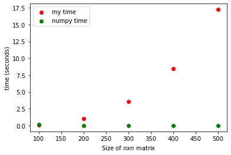

```python
plt.scatter(n_list,my_time, color='red', label = 'my time')
plt.scatter(n_list,numpy_time, color='green', label='numpy time')

plt.xlabel('Size of $n x n$ matrix');
plt.ylabel('time (seconds)')
plt.legend();
```

Based on the above results, you can see that the `numpy` algorithm not only is faster but also "scales" at a slower rate than your algorithm.

✅ **QUESTION:** Why do you think the `numpy` matrix multiplication is so much faster?

### Congratulations, we're done!

If you attend class in-person then have one of the instructors check your notebook and sign you out before leaving class. If you are attending asynchronously, turn in your assignment using D2L.

### MSU

Written by Dr. Dirk Colbry, Michigan State University and Dr. Ming Yan, Michigan State University  
This work is licensed under a [Creative Commons Attribution-NonCommercial 4.0 International License](http://creativecommons.org/licenses/by-nc/4.0/).